# Project: Investigate a Dataset - TMDb movie data Analysis

## Introduction

### Dataset Description

This data set contains information about 10,000 movies collected from The Movie Database (TMDb), including user ratings and revenue.

Certain columns, like ‘cast’ and ‘genres’, contain multiple values separated by pipe (|) characters.

There are some odd characters in the ‘cast’ column. Don’t worry about cleaning them. You can leave them as is.

The final two columns ending with “_adj” show the budget and revenue of the associated movie in terms of 2010 dollars, accounting for inflation over time.

All the columns in the data set and their respective significance: id - movies unique identifiers, imdb_id, popularity-how much the movie is known, budget-allocated cost of casting the movie, revenue - income received form movies, original_title - the title the movie was first released and known by , cast-team involved in the production, homepage-a link to where the movie is, director-the leader of the cast, tagline-a movies key phrase, keywords-what the movie is most likely going to be searched by, overview-a quick storyline of the movie, runtime-how long the movie shows, genres-the respective movie categories, production_companies-the company resposible for the movie, release_date-the date the movie was deployed to the public, vote_count-how many people have voted for a movie, vote_average-the average rating from the votes, release_year-the year the movie was released to the public, budget_adj-adjusted budget as at 2010 factoring in inflation, revenue_adj - adjusted revenue as at 20210 factoring in inflation

## Question(s) for Analysis

This analysis will particularly address the question(s).

- Which year has the highest average rating?
- Which year had the highest average revenue?
- Who are the directors of the top ten most popular movies??
- Which year had the highest average popularity?
- What kinds of properties are associated with movies that have high revenues?
  - Do movies with higher popularity receive better ratings?
  - Do movies with higher popularity bring in higher revenue?
  - Do movies with a higher runtime bring in more revenue?
  - Do movies with a higher budget bring in more revenue?
- Which year was the highest number of movies produced?
- The highest number of genres produced in the period of the data set and the specific type

```python
# Import statements for all of the packages intended for use.
import pandas as pd
import numpy as np
import matplotlib.pyplot as plt
import seaborn as sns
%matplotlib inline
```

## Data Wrangling

### Data wrangling and cleaning steps

1. Loading the csv data
2. Checking the first and last five row of the data to ensure it loaded properly
3. Checking the shape of the data in terms of the number of rows and columns
4. Checking the overall statistics of the numerical columns in entire data set to help quickly assess variables with missing data using describe
5. - Through general information, check for missing values, to ensure alignment with what the summary data suggested.
   - This general information about data set also informs us about; data types, no. of columns, rows and memory size
6. checking for the number of missing values in the dataset per column to determine the impact of missing values on your analysis and the decision as regards to handling missing data
7. Visualizing the missing data through a heatmap to get a visual outlook in comparison to the data from previous code
8. Checking for duplicates and the duplicates total to determine how to handle the duplicates thereafter based on the nature of the data set
9. Deleting the duplicates
10. Confimring the duplicates deletion success by checking the shape of the data again, that is, the number of rows and columns
11. Checking the number of uniques data in the data set per variable

#### By displaying the data in the tom five rows the table below helps us see how our data was loaded from CSV and the status it is in at the tom. You can extract information such as the first row in our data and how many columns are populated. We can then conclude that our data has uploaded successfully.

```python
# Loading csv data
df=pd.read_csv('tmdb-movies.csv')
df.head()
```

|  | id | imdb_id | popularity | budget | revenue | original_title | cast | homepage | director | tagline | ... | overview | runtime | genres | production_companies | release_date | vote_count | vote_average | release_year | budget_adj | revenue_adj |
| --- | --- | --- | --- | --- | --- | --- | --- | --- | --- | --- | --- | --- | --- | --- | --- | --- | --- | --- | --- | --- | --- |
| 0 | 135397 | tt0369610 | 32.985763 | 150000000 | 1513528810 | Jurassic World | Chris Pratt\|Bryce Dallas Howard\|Irrfan Khan\|Vi... | http://www.jurassicworld.com/ | Colin Trevorrow | The park is open. | ... | Twenty-two years after the events of Jurassic ... | 124 | Action\|Adventure\|Science Fiction\|Thriller | Universal Studios\|Amblin Entertainment\|Legenda... | 6/9/15 | 5562 | 6.5 | 2015 | 1.379999e+08 | 1.392446e+09 |
| 1 | 76341 | tt1392190 | 28.419936 | 150000000 | 378436354 | Mad Max: Fury Road | Tom Hardy\|Charlize Theron\|Hugh Keays-Byrne\|Nic... | http://www.madmaxmovie.com/ | George Miller | What a Lovely Day. | ... | An apocalyptic story set in the furthest reach... | 120 | Action\|Adventure\|Science Fiction\|Thriller | Village Roadshow Pictures\|Kennedy Miller Produ... | 5/13/15 | 6185 | 7.1 | 2015 | 1.379999e+08 | 3.481613e+08 |
| 2 | 262500 | tt2908446 | 13.112507 | 110000000 | 295238201 | Insurgent | Shailene Woodley\|Theo James\|Kate Winslet\|Ansel... | http://www.thedivergentseries.movie/#insurgent | Robert Schwentke | One Choice Can Destroy You | ... | Beatrice Prior must confront her inner demons ... | 119 | Adventure\|Science Fiction\|Thriller | Summit Entertainment\|Mandeville Films\|Red Wago... | 3/18/15 | 2480 | 6.3 | 2015 | 1.012000e+08 | 2.716190e+08 |
| 3 | 140607 | tt2488496 | 11.173104 | 200000000 | 2068178225 | Star Wars: The Force Awakens | Harrison Ford\|Mark Hamill\|Carrie Fisher\|Adam D... | http://www.starwars.com/films/star-wars-episod... | J.J. Abrams | Every generation has a story. | ... | Thirty years after defeating the Galactic Empi... | 136 | Action\|Adventure\|Science Fiction\|Fantasy | Lucasfilm\|Truenorth Productions\|Bad Robot | 12/15/15 | 5292 | 7.5 | 2015 | 1.839999e+08 | 1.902723e+09 |
| 4 | 168259 | tt2820852 | 9.335014 | 190000000 | 1506249360 | Furious 7 | Vin Diesel\|Paul Walker\|Jason Statham\|Michelle ... | http://www.furious7.com/ | James Wan | Vengeance Hits Home | ... | Deckard Shaw seeks revenge against Dominic Tor... | 137 | Action\|Crime\|Thriller | Universal Pictures\|Original Film\|Media Rights ... | 4/1/15 | 2947 | 7.3 | 2015 | 1.747999e+08 | 1.385749e+09 |

5 rows × 21 columns

#### By displaying the data in the bottom five rows the table below helps us see how our data was loaded from CSV and the status it is in at the bottom. You can extract information such as the last row in our data and how many columns are populated. We can then conclude that our data has uploaded successfully.

```python
# a view of the last five rows of the data set
df.tail()
```

|  | id | imdb_id | popularity | budget | revenue | original_title | cast | homepage | director | tagline | ... | overview | runtime | genres | production_companies | release_date | vote_count | vote_average | release_year | budget_adj | revenue_adj |
| --- | --- | --- | --- | --- | --- | --- | --- | --- | --- | --- | --- | --- | --- | --- | --- | --- | --- | --- | --- | --- | --- |
| 10861 | 21 | tt0060371 | 0.080598 | 0 | 0 | The Endless Summer | Michael Hynson\|Robert August\|Lord 'Tally Ho' B... | NaN | Bruce Brown | NaN | ... | The Endless Summer, by Bruce Brown, is one of ... | 95 | Documentary | Bruce Brown Films | 6/15/66 | 11 | 7.4 | 1966 | 0.000000 | 0.0 |
| 10862 | 20379 | tt0060472 | 0.065543 | 0 | 0 | Grand Prix | James Garner\|Eva Marie Saint\|Yves Montand\|Tosh... | NaN | John Frankenheimer | Cinerama sweeps YOU into a drama of speed and ... | ... | Grand Prix driver Pete Aron is fired by his te... | 176 | Action\|Adventure\|Drama | Cherokee Productions\|Joel Productions\|Douglas ... | 12/21/66 | 20 | 5.7 | 1966 | 0.000000 | 0.0 |
| 10863 | 39768 | tt0060161 | 0.065141 | 0 | 0 | Beregis Avtomobilya | Innokentiy Smoktunovskiy\|Oleg Efremov\|Georgi Z... | NaN | Eldar Ryazanov | NaN | ... | An insurance agent who moonlights as a carthie... | 94 | Mystery\|Comedy | Mosfilm | 1/1/66 | 11 | 6.5 | 1966 | 0.000000 | 0.0 |
| 10864 | 21449 | tt0061177 | 0.064317 | 0 | 0 | What's Up, Tiger Lily? | Tatsuya Mihashi\|Akiko Wakabayashi\|Mie Hama\|Joh... | NaN | Woody Allen | WOODY ALLEN STRIKES BACK! | ... | In comic Woody Allen's film debut, he took the... | 80 | Action\|Comedy | Benedict Pictures Corp. | 11/2/66 | 22 | 5.4 | 1966 | 0.000000 | 0.0 |
| 10865 | 22293 | tt0060666 | 0.035919 | 19000 | 0 | Manos: The Hands of Fate | Harold P. Warren\|Tom Neyman\|John Reynolds\|Dian... | NaN | Harold P. Warren | It's Shocking! It's Beyond Your Imagination! | ... | A family gets lost on the road and stumbles up... | 74 | Horror | Norm-Iris | 11/15/66 | 15 | 1.5 | 1966 | 127642.279154 | 0.0 |

5 rows × 21 columns

### Data Cleaning

```python
# number of rows and columns in the data set
print(df.shape)
```

```
(10866, 21)
```

```python
#Output of all columns
df.columns
```

```
Index(['id', 'imdb_id', 'popularity', 'budget', 'revenue', 'original_title',
       'cast', 'homepage', 'director', 'tagline', 'keywords', 'overview',
       'runtime', 'genres', 'production_companies', 'release_date',
       'vote_count', 'vote_average', 'release_year', 'budget_adj',
       'revenue_adj'],
      dtype='object')
```

#### The table below gives the overall statistics of the numerical columns in entire data set which help quickly assess variables with missing data and different aspects of our data set. For instance, from here we can conclude that we have a total of 10866 rows in our data set.

```python
#Summary statistics. Overall statistics of the numerical columns in entire data set will help quickly assess variables with missing data
df.describe()
```

|  | id | popularity | budget | revenue | runtime | vote_count | vote_average | release_year | budget_adj | revenue_adj |
| --- | --- | --- | --- | --- | --- | --- | --- | --- | --- | --- |
| count | 10866.000000 | 10866.000000 | 1.086600e+04 | 1.086600e+04 | 10866.000000 | 10866.000000 | 10866.000000 | 10866.000000 | 1.086600e+04 | 1.086600e+04 |
| mean | 66064.177434 | 0.646441 | 1.462570e+07 | 3.982332e+07 | 102.070863 | 217.389748 | 5.974922 | 2001.322658 | 1.755104e+07 | 5.136436e+07 |
| std | 92130.136561 | 1.000185 | 3.091321e+07 | 1.170035e+08 | 31.381405 | 575.619058 | 0.935142 | 12.812941 | 3.430616e+07 | 1.446325e+08 |
| min | 5.000000 | 0.000065 | 0.000000e+00 | 0.000000e+00 | 0.000000 | 10.000000 | 1.500000 | 1960.000000 | 0.000000e+00 | 0.000000e+00 |
| 25% | 10596.250000 | 0.207583 | 0.000000e+00 | 0.000000e+00 | 90.000000 | 17.000000 | 5.400000 | 1995.000000 | 0.000000e+00 | 0.000000e+00 |
| 50% | 20669.000000 | 0.383856 | 0.000000e+00 | 0.000000e+00 | 99.000000 | 38.000000 | 6.000000 | 2006.000000 | 0.000000e+00 | 0.000000e+00 |
| 75% | 75610.000000 | 0.713817 | 1.500000e+07 | 2.400000e+07 | 111.000000 | 145.750000 | 6.600000 | 2011.000000 | 2.085325e+07 | 3.369710e+07 |
| max | 417859.000000 | 32.985763 | 4.250000e+08 | 2.781506e+09 | 900.000000 | 9767.000000 | 9.200000 | 2015.000000 | 4.250000e+08 | 2.827124e+09 |

```python
#Checking for missing values, should align with what the summary data suggested
#General information about data set; data types, no. of columns, rows and others as below
df.info()
```

```
<class 'pandas.core.frame.DataFrame'>
RangeIndex: 10866 entries, 0 to 10865
Data columns (total 21 columns):
 #   Column                Non-Null Count  Dtype
---  ------                --------------  -----
 0   id                    10866 non-null  int64
 1   imdb_id               10856 non-null  object
 2   popularity            10866 non-null  float64
 3   budget                10866 non-null  int64
 4   revenue               10866 non-null  int64
 5   original_title        10866 non-null  object
 6   cast                  10790 non-null  object
 7   homepage              2936 non-null   object
 8   director              10822 non-null  object
 9   tagline               8042 non-null   object
 10  keywords              9373 non-null   object
 11  overview              10862 non-null  object
 12  runtime               10866 non-null  int64
 13  genres                10843 non-null  object
 14  production_companies  9836 non-null   object
 15  release_date          10866 non-null  object
 16  vote_count            10866 non-null  int64
 17  vote_average          10866 non-null  float64
 18  release_year          10866 non-null  int64
 19  budget_adj            10866 non-null  float64
 20  revenue_adj           10866 non-null  float64
dtypes: float64(4), int64(6), object(11)
memory usage: 1.7+ MB
```

```python
# checking for the number of missing values in the dataset per column
df.isnull().sum()
```

```
id                         0
imdb_id                   10
popularity                 0
budget                     0
revenue                    0
original_title             0
cast                      76
homepage                7930
director                  44
tagline                 2824
keywords                1493
overview                   4
runtime                    0
genres                    23
production_companies    1030
release_date               0
vote_count                 0
vote_average               0
release_year               0
budget_adj                 0
revenue_adj                0
dtype: int64
```

```python
#checking for duplicate values
df.duplicated().sum()
```

```
1
```

```python
#Output all rows that are duplicates
df[df.duplicated()]
```

|  | id | imdb_id | popularity | budget | revenue | original_title | cast | homepage | director | tagline | ... | overview | runtime | genres | production_companies | release_date | vote_count | vote_average | release_year | budget_adj | revenue_adj |
| --- | --- | --- | --- | --- | --- | --- | --- | --- | --- | --- | --- | --- | --- | --- | --- | --- | --- | --- | --- | --- | --- |
| 2090 | 42194 | tt0411951 | 0.59643 | 30000000 | 967000 | TEKKEN | Jon Foo\|Kelly Overton\|Cary-Hiroyuki Tagawa\|Ian... | NaN | Dwight H. Little | Survival is no game | ... | In the year of 2039, after World Wars destroy ... | 92 | Crime\|Drama\|Action\|Thriller\|Science Fiction | Namco\|Light Song Films | 3/20/10 | 110 | 5.0 | 2010 | 30000000.0 | 967000.0 |

1 rows × 21 columns

```python
#removing duplicate values from our data set
df.drop_duplicates(inplace=True)
```

```python
#validating the removal of duplicate values
print(df.shape)
```

```
(10865, 21)
```

```python
#Unique values
df.nunique()
```

```
id                      10865
imdb_id                 10855
popularity              10814
budget                    557
revenue                  4702
original_title          10571
cast                    10719
homepage                 2896
director                 5067
tagline                  7997
keywords                 8804
overview                10847
runtime                   247
genres                   2039
production_companies     7445
release_date             5909
vote_count               1289
vote_average               72
release_year               56
budget_adj               2614
revenue_adj              4840
dtype: int64
```

## Exploratory Data Analysis

### Which year has the highest average rating?

```python
#For ease of reference of columns
df.columns
```

```
Index(['id', 'imdb_id', 'popularity', 'budget', 'revenue', 'original_title',
       'cast', 'homepage', 'director', 'tagline', 'keywords', 'overview',
       'runtime', 'genres', 'production_companies', 'release_date',
       'vote_count', 'vote_average', 'release_year', 'budget_adj',
       'revenue_adj'],
      dtype='object')
```

```python
df.groupby('release_year')['vote_average'].mean().sort_values(ascending=False)
```

```
release_year
1973    6.703636
1972    6.535000
1971    6.420000
1970    6.417073
1974    6.395745
1975    6.390909
1968    6.379487
1961    6.374194
1962    6.343750
1976    6.340426
1963    6.329412
1960    6.325000
1979    6.308772
1967    6.242500
```

[output cut: 43 more lines]

#### Below is a visualization of the highest average rating by year, where can extract the average rating of all respective years. We can then conclude that the year with the highest average rating is the year 1973.

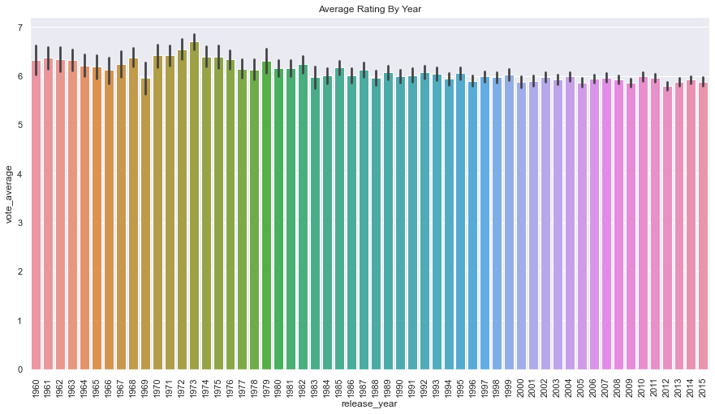

```python
#visualization of the highest average rating by year
sns.set(rc={'figure.figsize':(15,8)})
sns.barplot(x='release_year',y='vote_average',data=df)
locs,labels=plt.xticks()
plt.setp(labels,rotation=90)
plt.title("Average Rating By Year")
plt.show()
```

```python
# a function that calls the top average rating
def top_rating():
    print("6.703636, ","1973")
```

```python
# a function that calls the lowest average rating
def low_rating():
    print("5.799830, ","2012")
```

### Which year has the highest average revenue?

```python
df.groupby('release_year')['revenue_adj'].mean().sort_values(ascending=False)
```

```
release_year
1977    1.376362e+08
1967    1.205763e+08
1973    1.092939e+08
1965    9.057670e+07
1979    8.880802e+07
1975    8.817223e+07
1961    7.947167e+07
1970    7.674178e+07
1974    7.645280e+07
1997    7.538870e+07
1995    7.487098e+07
1992    7.101953e+07
1978    7.044251e+07
1982    6.858277e+07
```

[output cut: 43 more lines]

#### The following is a visualization of the average highest revenue by year, where can extract the average revenue of all respective years. We can then conclude that the year with the highest average revenue is the year 1977.

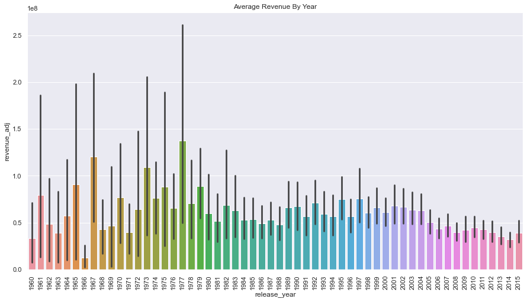

```python
#visualization of the highest average revenue by year
sns.set(rc={'figure.figsize':(15,8)})
sns.barplot(x='release_year',y='revenue_adj',data=df)
locs,labels=plt.xticks()
plt.setp(labels,rotation=90)
plt.title("Average Revenue By Year")
plt.show()
```

```python
# a function that calls the top average revenue
def top_revenue():
    print("1.376362e+08, ","1977")
```

```python
# a function that calls the lowest average revenue
def low_revenue():
    print("1.237527e+07, ","1966")
```

### Who are the directors of the top ten most popular movies?

```python
df.columns
```

```
Index(['id', 'imdb_id', 'popularity', 'budget', 'revenue', 'original_title',
       'cast', 'homepage', 'director', 'tagline', 'keywords', 'overview',
       'runtime', 'genres', 'production_companies', 'release_date',
       'vote_count', 'vote_average', 'release_year', 'budget_adj',
       'revenue_adj'],
      dtype='object')
```

#### The table below shows the top ten movies through all the years in the data set by popularity. We can extract other information related to the top ten popular movies such as genre, release year, director, budget and revenue. From here we can conclude that the most popular movie through all the years is Jurassic World.

```python
#top ten popular genres and their respective variables as following
top10_popular=df.nlargest(10,'popularity')[['popularity','original_title','release_year','genres','director','budget_adj','revenue_adj']]
```

```python
top10_popular
```

|  | popularity | original_title | release_year | genres | director | budget_adj | revenue_adj |
| --- | --- | --- | --- | --- | --- | --- | --- |
| 0 | 32.985763 | Jurassic World | 2015 | Action\|Adventure\|Science Fiction\|Thriller | Colin Trevorrow | 1.379999e+08 | 1.392446e+09 |
| 1 | 28.419936 | Mad Max: Fury Road | 2015 | Action\|Adventure\|Science Fiction\|Thriller | George Miller | 1.379999e+08 | 3.481613e+08 |
| 629 | 24.949134 | Interstellar | 2014 | Adventure\|Drama\|Science Fiction | Christopher Nolan | 1.519800e+08 | 5.726906e+08 |
| 630 | 14.311205 | Guardians of the Galaxy | 2014 | Action\|Science Fiction\|Adventure | James Gunn | 1.565855e+08 | 7.122911e+08 |
| 2 | 13.112507 | Insurgent | 2015 | Adventure\|Science Fiction\|Thriller | Robert Schwentke | 1.012000e+08 | 2.716190e+08 |
| 631 | 12.971027 | Captain America: The Winter Soldier | 2014 | Action\|Adventure\|Science Fiction | Joe Russo\|Anthony Russo | 1.565855e+08 | 6.583651e+08 |
| 1329 | 12.037933 | Star Wars | 1977 | Adventure\|Action\|Science Fiction | George Lucas | 3.957559e+07 | 2.789712e+09 |
| 632 | 11.422751 | John Wick | 2014 | Action\|Thriller | Chad Stahelski\|David Leitch | 1.842182e+07 | 7.252661e+07 |
| 3 | 11.173104 | Star Wars: The Force Awakens | 2015 | Action\|Adventure\|Science Fiction\|Fantasy | J.J. Abrams | 1.839999e+08 | 1.902723e+09 |
| 633 | 10.739009 | The Hunger Games: Mockingjay - Part 1 | 2014 | Science Fiction\|Adventure\|Thriller | Francis Lawrence | 1.151364e+08 | 6.927528e+08 |

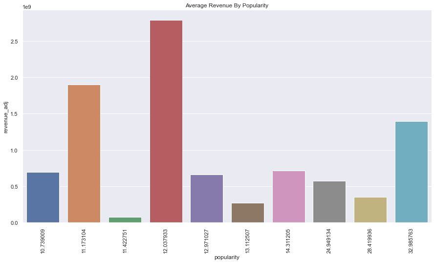

```python
#visualization of the top 10 popular movies by revenue
sns.set(rc={'figure.figsize':(15,8)})
sns.barplot(x='popularity',y='revenue_adj',data=top10_popular)
locs,labels=plt.xticks()
plt.setp(labels,rotation=90)
plt.title("Average Revenue By Popularity")
plt.show()
```

#### Here is a visualization of the budget versus the popularity of the top ten popular movies, where can extract the average budget in comparison to popularity for the top ten movies. We can then conclude that the higher the budget is not necessarity the higher the popularity.

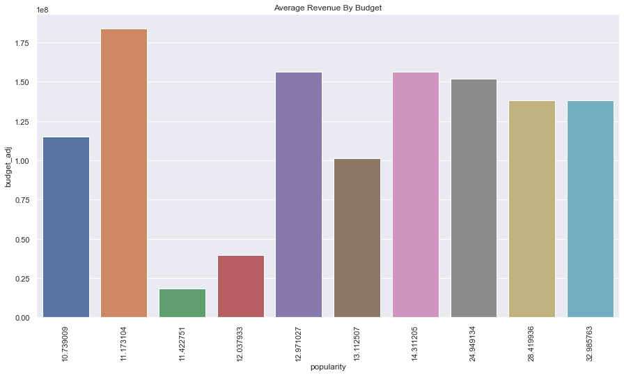

```python
#visualization of the top 10 popular movies by budget
sns.set(rc={'figure.figsize':(15,8)})
sns.barplot(x='popularity',y='budget_adj',data=top10_popular)
locs,labels=plt.xticks()
plt.setp(labels,rotation=90)
plt.title("Average Revenue By Budget")
plt.show()
```

#### Below is visualization of the spread of the top ten movies across the years represented in the data set. We can extract the exact years in which the top ten movies were produced and at what rate of popularity per year. We can conclude that the most popular movies in the top ten list were produced in the year 2015.

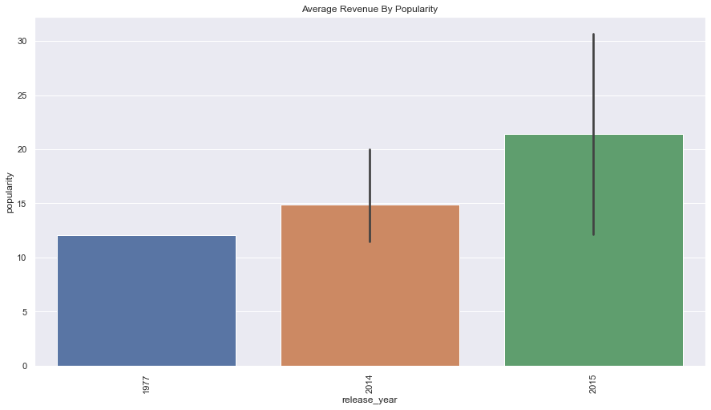

```python
#visualization of the top 10 popular movies by year
sns.set(rc={'figure.figsize':(15,8)})
sns.barplot(x='release_year',y='popularity',data=top10_popular)
locs,labels=plt.xticks()
plt.setp(labels,rotation=90)
plt.title("Average Revenue By Popularity")
plt.show()
```

### Which year has the highest average popularity?

```python
df.groupby('release_year')['popularity'].mean().sort_values(ascending=False)
```

```
release_year
2015    1.030657
2014    0.887268
2004    0.722438
2003    0.719083
1997    0.712003
1995    0.710722
2001    0.702658
2002    0.701454
2011    0.675069
1994    0.668825
1999    0.645799
2010    0.645058
2005    0.628663
2013    0.627627
```

[output cut: 43 more lines]

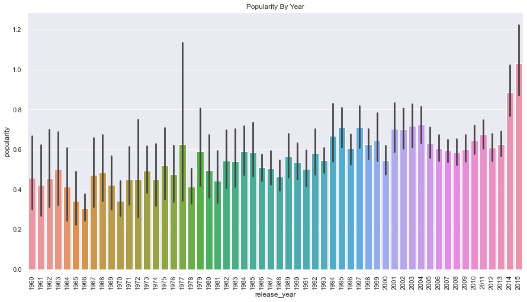

```python
#visualization of the highest average popularity by year
sns.set(rc={'figure.figsize':(15,8)})
sns.barplot(x='release_year',y='popularity',data=df)
locs,labels=plt.xticks()
plt.setp(labels,rotation=90)
plt.title("Popularity By Year")
plt.show()
```

#### Above is a visualization of the spread movies popularity across the years represented in the data set. We can extract the trend of movies popularity across the years. We conclude that the most popular movies were produced in the year 2015.¶

```python
# a function that calls the highest average popularity
def top_popularity():
    print("1.030657, ","2015")
```

```python
# a function that calls the lowest average popularity
def low_popularity():
    print("0.304112, ","1966")
```

### Do movies with higher popularity receive better ratings?

```python
# get the median amount of popularity
df.popularity.median()
```

```
0.383831
```

```python
# select samples with popularity less than the median
low_popularity = df.query('popularity < 0.383831')

# select samples with popularity greater than or equal to the median
high_popularity = df.query('popularity >= 0.383831')

# ensure these queries included each sample exactly once
num_samples = df.shape[0]
num_samples == low_popularity['vote_average'].count() + high_popularity['vote_average'].count() # should be True
```

```
True
```

```python
# get mean rating for the low popularity and high popularity groups
low_popularity.vote_average.mean(), high_popularity.vote_average.mean()
```

```
(5.8539580265095585, 6.096042702006258)
```

### Do movies with higher popularity bring in higher revenue?

```python
# ensure these queries included each sample exactly once
num_samples = df.shape[0]
num_samples == low_popularity['revenue_adj'].count() + high_popularity['revenue_adj'].count() # should be True
```

```
True
```

```python
# get mean revenue for the low popularity and high popularity groups
low_popularity.revenue_adj.mean(), high_popularity.revenue_adj.mean()
```

```
(6711786.024770956, 96017997.8691826)
```

### Do movies with a higher runtime bring in more revenue?

```python
# get the median amount of runtime
df.runtime.median()
```

```
99.0
```

```python
# select samples with runtime less than the median
low_runtime = df.query('runtime < 99.0')

# select samples with popularity greater than or equal to the median
high_runtime = df.query('runtime >= 99.0')

# ensure these queries included each sample exactly once
num_samples = df.shape[0]
num_samples == low_runtime['revenue_adj'].count() + high_runtime['revenue_adj'].count() # should be True
```

```
True
```

```python
# get mean revenue for the low runtime and high runtime groups
low_runtime.revenue_adj.mean(), high_runtime.revenue_adj.mean()
```

```
(23600728.52145682, 78625767.50088368)
```

### Do movies with a higher budget bring in more revenue?

```python
# get the median amount of budget
df.budget_adj.mean()
```

```
17549894.037320614
```

```python
# select samples with budget less than the mean
low_budget_adj = df.query('budget_adj < 17549894.037320614')

# select samples with popularity greater than or equal to the median
high_budget_adj = df.query('budget_adj >= 17549894.037320614')

# ensure these queries included each sample exactly once
num_samples = df.shape[0]
num_samples == low_budget_adj['revenue_adj'].count() + high_budget_adj['revenue_adj'].count() # should be True
```

```
True
```

```python
# get mean revenue for the low budget and high budget groups
low_budget_adj.revenue_adj.mean(), high_budget_adj.revenue_adj.mean()
```

```
(10401033.133470457, 160070494.839815)
```

### Which year was the highest number of movies produced?

```python
df['release_year'].value_counts()
```

```
2014    700
2013    659
2015    629
2012    588
2011    540
2009    533
2008    496
2010    489
2007    438
2006    408
2005    364
2004    307
2003    281
2002    266
2001    242
```

[output cut: 42 more lines]

#### Below is visualization of the count of movies produced across the years represented in the data set. From here we can extract the number of movies produced per year. We can conclude that most movies were produced in the year 2014.¶

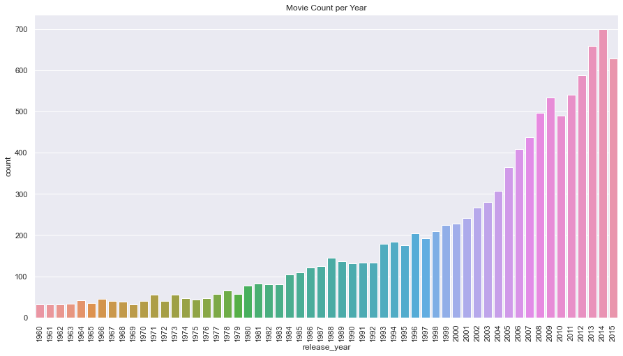

```python
sns.set(rc={'figure.figsize':(15,8)})
sns.countplot(x='release_year', data=df)
locs,labels=plt.xticks()
plt.setp(labels,rotation=90)
plt.title("Movie Count per Year")
plt.show()
```

### The highest number of genres produced in the period of the data set and the specific type

```python
df['genres'].value_counts()
```

```
Comedy                                      712
Drama                                       712
Documentary                                 312
Drama|Romance                               289
Comedy|Drama                                280
                                           ...
Adventure|Animation|Romance                   1
Family|Animation|Drama                        1
Action|Adventure|Animation|Comedy|Family      1
Action|Adventure|Animation|Fantasy            1
Mystery|Science Fiction|Thriller|Drama        1
Name: genres, Length: 2039, dtype: int64
```

[figure not shown]

```python
sns.set(rc={'figure.figsize':(15,8)})
sns.countplot(x='release_year', data=df)
locs,labels=plt.xticks()
plt.setp(labels,rotation=90)
plt.title("Genre Count per Year")
plt.show()
```

#### From the following functions we can tell the year with the top average revenue is not necessarily the same year with the top average rating nor the top popularity. The same can be concluded for the lowest of these average figures.

#### These functions make the analysis user friendly as it is easy to refer to these figures without necessarily scrolling through the codes.

```python
top_revenue()
top_rating()
top_popularity()
```

```
1.376362e+08,  1977
6.703636,  1973
1.030657,  2015
```

```python
low_revenue()
low_rating()
low_popularity()
```

```
1.237527e+07,  1966
5.799830,  2012
0.304112,  1966
```

## Conclusions

### Summary findings and results

**Which year has the highest average rating?** The highest average rating is in the year 1973 at 6.7.

**Who are the directors of the top ten most popular movies??** Colin Trevorrow, George Miller, Christopher Nolan, James Gunn, Robert Schwentke, Joe Russo and Anthony Russo, George Lucas, Chad Stahelski and David Leitch, J.J. Abrams and finally Francis Lawrence.

**Which year had the highest average popularity?** The year with the average popularity is 2015 at 1.03.

**Which year was the highest number of movies produced?** The highest number of movies were produced in the year 2014 at 700 movies

**The highest number of genres produced in the period of the data set and the specific type.** The genres most produced are Comedy and Drama movies at 712 counts each over the data set period of 56 years

In conclusion, additional research can be done to analyze the power of competition with regards to subtitute movies in similary genre in correlarion to revenue. As well as the total number of movies produced in a year in correlation to revenue.

### Limitations

One key limitation of this research is that the mean or median computations computed in say the average revenue, average rating, average popularity may be a bit skewed to the right or to the left depending on which side has the highest number of zero figures.